# Munich DataGeeks - Playing with the Meetup Data

Given that Datageeks Meetup is about cool things to do with data, let's see what we can do with a bit of processing to the data we have available.

Let's start by getting nice defaults and setting up some helpful code. I based the style of using the recommendations and code on the Harvard course on Data Science http://cs109.org/ - Totally recommended resource on learning both Data Science and how to do it with IPtyhon Notebooks.

```python
#import basic tools and change default colors

%load_ext autoreload
%autoreload 2

import numpy as np
import pandas as pd
import matplotlib.pyplot as plt
import matplotlib as mpl
import brewer2mpl
from matplotlib import rcParams

# Change the default colors
dark2_colors = brewer2mpl.get_map('Paired', 'Qualitative', 7).mpl_colors

rcParams['figure.figsize'] = (10, 10)
rcParams['figure.dpi'] = 200
rcParams['axes.color_cycle'] = dark2_colors
rcParams['lines.linewidth'] = 2
rcParams['axes.facecolor'] = 'white'
rcParams['font.size'] = 10
rcParams['patch.edgecolor'] = 'white'
rcParams['patch.facecolor'] = dark2_colors[0]
rcParams['font.family'] = 'StixGeneral'

%matplotlib inline
#%matplotlib qt
```

```
The autoreload extension is already loaded. To reload it, use:
  %reload_ext autoreload
```

## RSVP Comparison

We already had multiple meetups since we started the meetup group. Let's have a look at the trends.

First prepare the data ...

```python
events = ['July', 'August', 'October',
          'November', 'January', 'February',
          'March', 'June', 'August']

# format: (attendees, waitlisted)
rsvps = [(84, 0), (58, 0), (61, 0), (103, 0), (74, 2), (70, 23), (103, 0), (87, 22), (90, 39)]
attendees = [ elem[0] for elem in rsvps ]
waitlisted = [ elem[1] for elem in rsvps ]
overall = [ sum(elem) for elem in rsvps ]

x_pos = np.arange(len(events))
box_colors = brewer2mpl.get_map('Set3', 'Qualitative', len(events), reverse=True).mpl_colors
```

... then define plotting function (reusable code).

```python
def plot_attendees(show_waitlisted=False, trendline=False, save=None):
    plt.figure(figsize=(14, 8))
    plt.ylim([0,150])
    plt.xticks(x_pos, events)
    ax = plt.subplot(111)

    # Remove top axes
    ax.spines['top'].set_visible(False)
    ax.spines['right'].set_visible(False)
    ax.spines['left'].set_visible(False)

    # remove ticks
    ax.yaxis.set_ticks_position('none')
    ax.xaxis.set_ticks_position('none')

    ax.grid(axis='y', color='white', linestyle='-')

    for i, rsvp, color in zip(x_pos, attendees, box_colors):
        ax.bar(i, rsvp, align='center', color=color, linewidth=0)
        ax.annotate("{}".format(rsvp), (i, rsvp + 1), va="bottom", ha="center")

    if show_waitlisted:
        for i, rsvp, color in zip(x_pos, waitlisted, box_colors):
            ax.bar(i, rsvp, align='center', color=color, linewidth=0, bottom=attendees[i], alpha=0.5)
            if rsvp != 0:
                ax.annotate("{}".format(overall[i]), (i, rsvp + attendees[i] + 2), va="bottom", ha="center")

    if trendline:
        z = np.polyfit(x_pos, overall, 2)
        p = np.poly1d(z)
        plt.plot(x_pos, p(x_pos), "k--")

    if save:
        plt.savefig(save, dpi=200)

    plt.show()
    plt.close()
```

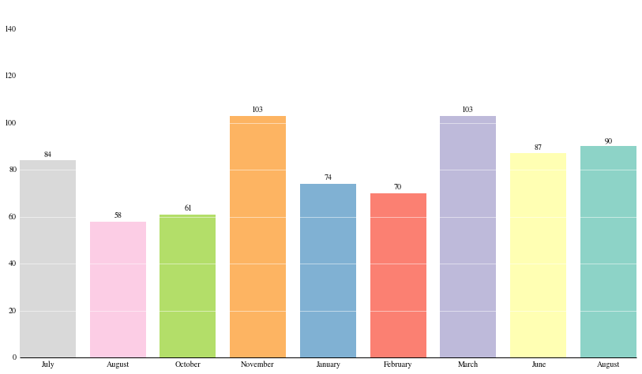

```python
plot_attendees(save="hist-attendees")
```

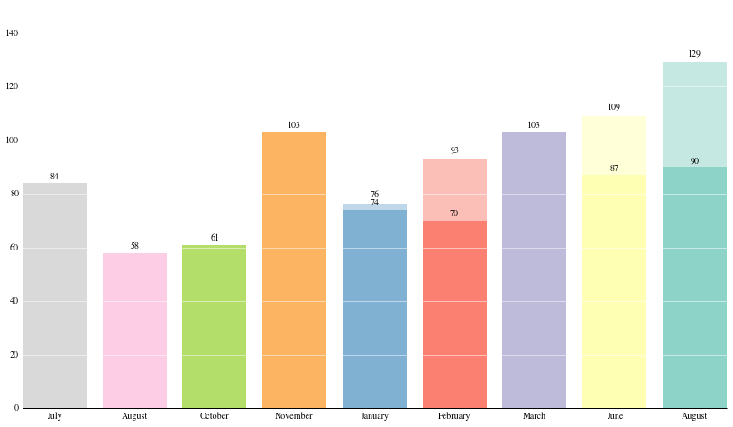

```python
plot_attendees(show_waitlisted=True, save="hist-attendees-waitlisted")
```

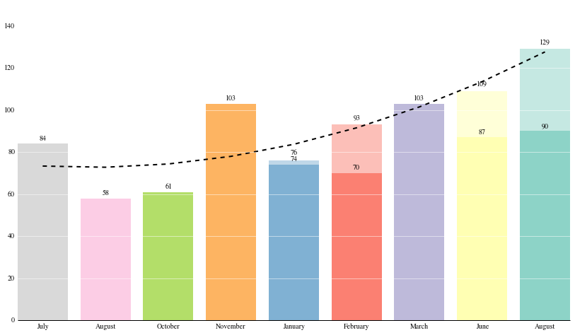

```python
plot_attendees(show_waitlisted=True, trendline=True, save="hist-attendees-waitlisted-trendline")
```

## Playing with Meetup.com API

It turns out you can get meta-info from the meetups via API. You just need a key to query it. So let's do the best you can do when you have data of users: *stalk people*.

So let's get the data:

```python
%%bash
key=$(cat meetup_apikey.txt)
curl "http://api.meetup.com/2/members?order=name&group_urlname=Munich-Datageeks&offset=0&format=json&key=${key}" > members.json
```

Let's first create a nice function to graph stuff again.

```python
def plot_count_graph(data_tuples, path, color_index=0):
    plt.figure(figsize=(10, 6))
    ax = plt.subplot(111)

    color = brewer2mpl.get_map('Set3', 'Qualitative', 5).mpl_colors[color_index]

    y_pos = np.arange(len(data_tuples))
    counts = [ j  for i, j in data_tuples ]
    plt.yticks(y_pos, [ i  for i, j in data_tuples ])
    plt.xlim([0, counts[-1] + 10])

    # remove border of plot - should be possible to do it in an easier way!
    ax.spines['top'].set_visible(False)
    ax.spines['right'].set_visible(False)
    ax.spines['bottom'].set_visible(False)
    ax.xaxis.set_ticks([])
    ax.get_yaxis().tick_left()

    padding = 3 if counts[-1] > 100 else 0.5
    for i, count in enumerate(counts):
        ax.barh(i, count, align='center', linewidth=0, color=color)
        ax.annotate(str(count), (count + padding, i), va="center", ha="center")

    plt.grid(axis='x', color='white', linestyle='-')

    plt.savefig(path, dpi=300, bbox_inches='tight')
    plt.show()
    plt.close()
```

With the previously defined function we are going to write code to get the TOP-15 interests of the Datageeks community:

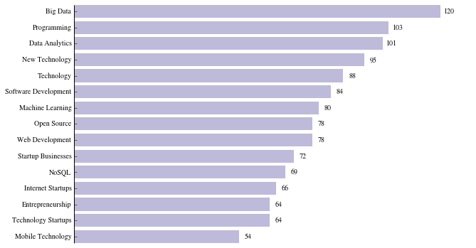

```python
import json
from operator import itemgetter
from collections import Counter

interest_counter = Counter()

with open('members.json') as f:
    member_data = json.load(f)
    for user in member_data['results']:
        for interest in user['topics']:
            interest_counter[interest['name']] += 1

plot_count_graph(interest_counter.most_common()[0:15][::-1], "interests", color_index=2)
```

### Let's keep stalking people

I am quite interested in what people write on their bio. Let's see if there are common terms.

First, preparing some helper functions and getting ready.

```python
from sklearn.feature_extraction.text import CountVectorizer
from itertools import tee, izip
import nltk
from nltk.corpus import stopwords

# in order to be able to use the NLTK stopwords corpus,
# you need to download it first: http://www.nltk.org/data.html
nltk.download("stopwords")

# itertools recipe
def pairwise(iterable):
    "s -> (s0,s1), (s1,s2), (s2, s3), ..."
    a, b = tee(iterable)
    next(b, None)
    return izip(a, b)

def get_unigrams(bio):
    unigrams_all = bio.strip().replace(',', '').replace('@', '').lower().split(' ')
    filter_func = lambda x: x and x not in stopwords.words('english') + ['hi', "i'm"]
    return filter(filter_func, unigrams_all)
```

Now, let's have a look at the most common unigrams.

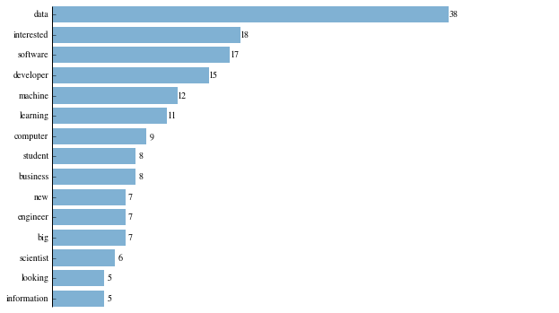

```python
wordcounts_unigrams = Counter()
# we still have the variable "member_data" in our scope
for member in member_data['results']:
    if 'bio' in member:
        # this is just a quick and easy tokenization which is good enough for our purpose
        # for more sophisticated tokenization: http://www.nltk.org/api/nltk.tokenize.html
        unigrams = get_unigrams(member['bio'])
        wordcounts_unigrams.update(unigrams)

# now we can reuse the plot_count_graph function defined earlier
plot_count_graph(wordcounts_unigrams.most_common()[:15][::-1], "unigrams", color_index=4)
```

Well, that's nice but not really that much telling. We expected **data** to be at the top and it looks like plotting the graph based on bigrams would make more sense. So let's to just that.

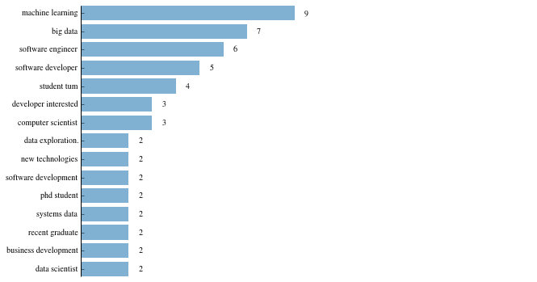

```python
wordcounts_bigrams = Counter()
for member in member_data['results']:
    if 'bio' in member:
        unigrams = get_unigrams(member['bio'])
        bigrams = [ " ".join(pair) for pair in pairwise(unigrams) ]
        wordcounts_bigrams.update(bigrams)

plot_count_graph(wordcounts_bigrams.most_common()[:15][::-1], "bigrams", color_index=4)
```

Another interesting data source of meetup.com is the groups and the data attached to them, like number of members, rating, city, and country.  
The API allows you to get 200 groups for one specific topic, e.g. "Machine Learning".  
I am going to get data for three topics: Machine Learning, Data Science, and Big Data.

```python
%%bash
key=$(cat meetup_apikey.txt)
curl "http://api.meetup.com/2/groups.json/?topic=machine-learning&offset=0&order=members&key=${key}" > ml_groups.json
curl "http://api.meetup.com/2/groups.json/?topic=data-science&order=members&key=${key}" > ds_groups.json
curl "http://api.meetup.com/2/groups.json/?topic=big-data&order=members&key=${key}" > bd_groups.json
```

Now get the data in the format we want it to be.

```python
from collections import defaultdict

def get_group_data(path):
    data = defaultdict(dict)
    with open(path) as f:
        group_data = json.load(f)

    for group in group_data["results"]:
        # I am assuming that the name is unique
        name = group["name"]
        data[name]["city"] = group["city"]
        data[name]["country"] = group["country"]
        data[name]["rating"] = group["rating"]
        data[name]["members"] = group["members"]

    # the api response only gives you data about the top 200 groups
    # hence, we need to get the total number of groups this way
    total_count = group_data["meta"]["total_count"]
    return data, total_count

ml_data, ml_total_count = get_group_data("ml_groups.json")
ds_data, ds_total_count = get_group_data("ds_groups.json")
bd_data, bd_total_count = get_group_data("bd_groups.json")
```

This kind of structured data really screams pandas DataFrame at me :)

```python
ml_df = pd.DataFrame.from_dict(ml_data, orient='index')
ds_df = pd.DataFrame.from_dict(ds_data, orient='index')
bd_df = pd.DataFrame.from_dict(bd_data, orient='index')
```

Hmm...which of the three topics is more popular?

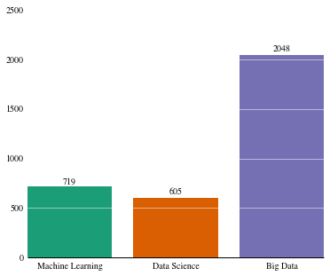

```python
# code very similar to "plot_attendees" function - should be refactored (once I have time)
plt.figure(figsize=(6, 5))
topics = ["Machine Learning", "Data Science", "Big Data"]
counts = [ml_total_count, ds_total_count, bd_total_count]
colors = brewer2mpl.get_map('Dark2', 'Qualitative', len(topics)).mpl_colors

x_pos = np.arange(3)
plt.xticks(x_pos, topics)
ax = plt.subplot(111)

# Remove top axes
ax.spines['top'].set_visible(False)
ax.spines['right'].set_visible(False)
ax.spines['left'].set_visible(False)

# remove ticks
ax.yaxis.set_ticks_position('none')
ax.xaxis.set_ticks_position('none')
ax.grid(axis='y', color='white', linestyle='-')

for i, topic, color in zip(x_pos, topics, colors):
        ax.bar(i, counts[i], align='center', color=color, linewidth=0)
        ax.annotate("{}".format(counts[i]), (i, counts[i] + 20), va="bottom", ha="center")

plt.savefig("group_total_counts", dpi=200)
plt.show()
plt.close()
```

In the following, I will only analyze the "Machine Learning" groups. The same could be done for all the other group data of course.

List all the groups in Munich which have "Machine Learning" as one of their topics (remember that we only consider the top 200 groups based on number of members).

```python
ml_df[ml_df.city == u'München']
```

|  | city | rating | members | country |
| --- | --- | --- | --- | --- |
| Munich Datageeks | München | 4.65 | 618 | DE |

1 rows × 4 columns

Now let's just get a quick overview of the data to know what we're dealing with here.

```python
ml_df.describe()
```

|  | rating | members |
| --- | --- | --- |
| count | 200.000000 | 200.000000 |
| mean | 4.372400 | 915.615000 |
| std | 0.913214 | 973.938911 |
| min | 0.000000 | 275.000000 |
| 25% | 4.427500 | 378.750000 |
| 50% | 4.560000 | 543.000000 |
| 75% | 4.710000 | 1004.250000 |
| max | 5.000000 | 6390.000000 |

8 rows × 2 columns

Next up, let's see where Meetups are quite popular - first on a country basis, then on a city basis.

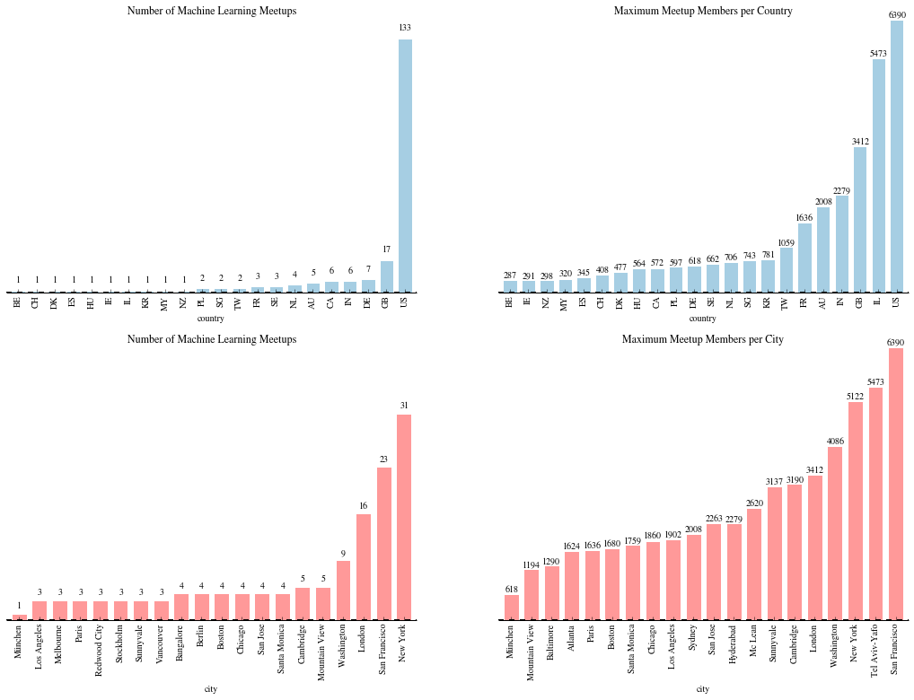

```python
# group dataframe by city or country
ml_df_city = ml_df.groupby("city")
ml_df_country = ml_df.groupby("country")

def apply_plot_settings(counts):
    ax = plt.gca()
    ax.spines['right'].set_color('none')
    ax.spines['top'].set_color('none')
    ax.spines['left'].set_color('none')
    ax.xaxis.set_ticks_position('bottom')
    plt.yticks([])
    plt.ylim([0, counts[-1] + 10])

    padding = 3 if counts[-1] > 100 else 0.5
    for i, count in enumerate(counts):
        # the i + 0.65 is a little weird and I think necessary because of the pandas plot wrapper
        # well, it works
        ax.annotate("{}".format(count), (i + 0.65, count + padding), va="bottom", ha="center")

# now the plotting starts
plt.figure(figsize=(18, 12))

plt.subplot(221)
apply_plot_settings(ml_df_country.count().rating.order())
ml_df_country.count().rating.order().plot(kind='bar', title='Number of Machine Learning Meetups', grid=False)

plt.subplot(222)
apply_plot_settings(ml_df_country.members.max().order())
ml_df_country.members.max().order().plot(kind='bar', title='Maximum Meetup Members per Country', grid=False)

plt.subplot(223)
# we want to have Munich in the plot :)
city_count_top = ml_df_city.count().rating.order()[-19:]
city_count_top[u'München'] = ml_df_city.count().rating[u"München"]
apply_plot_settings(city_count_top.order())
city_count_top.order().plot(kind='bar', title='Number of Machine Learning Meetups', grid=False, facecolor='#ff9999')

plt.subplot(224)
# we want to have Munich in the plot :)
city_members_top = ml_df_city.members.max().order()[-19:]
city_members_top[u'München'] = ml_df_city.members.max()[u"München"]
apply_plot_settings(city_members_top.order())
city_members_top.order().plot(kind='bar', title='Maximum Meetup Members per City', grid=False, facecolor='#ff9999')
plt.savefig('country_city_stats', dpi=200)
```

Wow! These plots really shed a bad light on Munich as it looks like Munich is always in the last position. Time to change that by looking at what cities we are ahead of :)

First, how do we rank within Germany?

```python
ml_df[ml_df.country == "DE"].sort(columns=["members"], ascending=False)[["members", "city"]]
```

|  | members | city |
| --- | --- | --- |
| Munich Datageeks | 618 | München |
| Berlin Machine learning group | 591 | Berlin |
| SoundCloud Tech Meetups | 407 | Berlin |
| Algorithms & Data Challenges Berlin | 394 | Berlin |
| Big Data & NoSQL Meetup Hamburg | 382 | Hamburg |
| 12min.me | 311 | Hamburg |
| Data Science Berlin | 302 | Berlin |

7 rows × 2 columns

Now, what other cities do we surpass in number of members?

```
Number of surpassed cities: 36
```

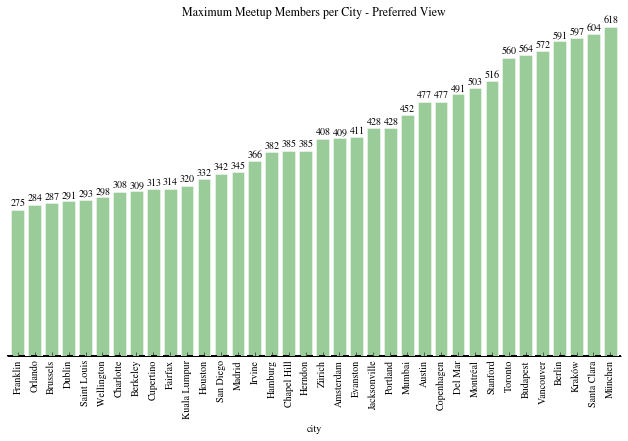

```python
max_members_munich = ml_df_city.members.max()[u"München"]
surpassed = ml_df_city.members.max().order()[ml_df_city.members.max().order() <= max_members_munich]
print "Number of surpassed cities: {}".format(surpassed.count())
plt.figure(figsize=(11, 6))
apply_plot_settings(surpassed)
surpassed.plot(kind='bar', title='Maximum Meetup Members per City - Preferred View', grid=False, color="green", alpha=0.4)
plt.savefig('surpassed_cities', dpi=200)
```

## What else could we explore?

- compare number of members per city with number of residents (or maybe even with number of IT professionals)
- analyze the "rating" column in more detail, e.g. "Are ratings in USA better than in Germany?"
- we have Google Analytics activated for our Meetup web page, so we could dig into that

## Inspiration and Reference

Some interesting liks regarding visualization of data and Data Science in general:

- https://drive.google.com/folderview?id=0BxYkKyLxfsNVd0xicUVDS1dIS0k&usp=sharing
- http://nbviewer.ipython.org/5357268
- http://nbviewer.ipython.org/urls/raw.github.com/cs109/content/master/lec_03_statistical_graphs.ipynb